# CCGL9065: Our Response to Climate Change: HK2100

Architecture and Cities

Dr. Hongshan Guo and Class

# Last Week’s Strategy: Sensory Hijack

## Quick Callback

Last week’s strategy: **Sensory Hijack**

*The body believes what the mind resists.*

**Anyone try it?** Did you make your audience physically uncomfortable — on purpose?

## Something You Took Away Last Week

Week 4 gave you a new lens: **timing changes everything.**

The Duck Curve showed you that solar energy isn’t just about *how much* — it’s about *when.*

- The sun shines when you don’t need power.
- Demand peaks exactly when supply drops.
- A “clean” grid can collapse if you ignore the clock.

System boundaries aren’t just spatial — they’re **temporal.** And that matters even more when you scale up to cities.

## From Energy Grids → The Built Environment

Last week: *“When does the energy flow?”*

This week: *“What did we build — and what does it cost the planet?”*

**Same systems thinking. Biggest system boundary yet.**

A city is the ultimate system — energy, water, waste, transport, people — all interacting inside a boundary of concrete and glass that traps heat, consumes resources, and reshapes the climate around it.

Your toolkit is growing: Spectacle Formula → Complexity → System Boundaries → Timing → **now: the built environment as climate actor.**

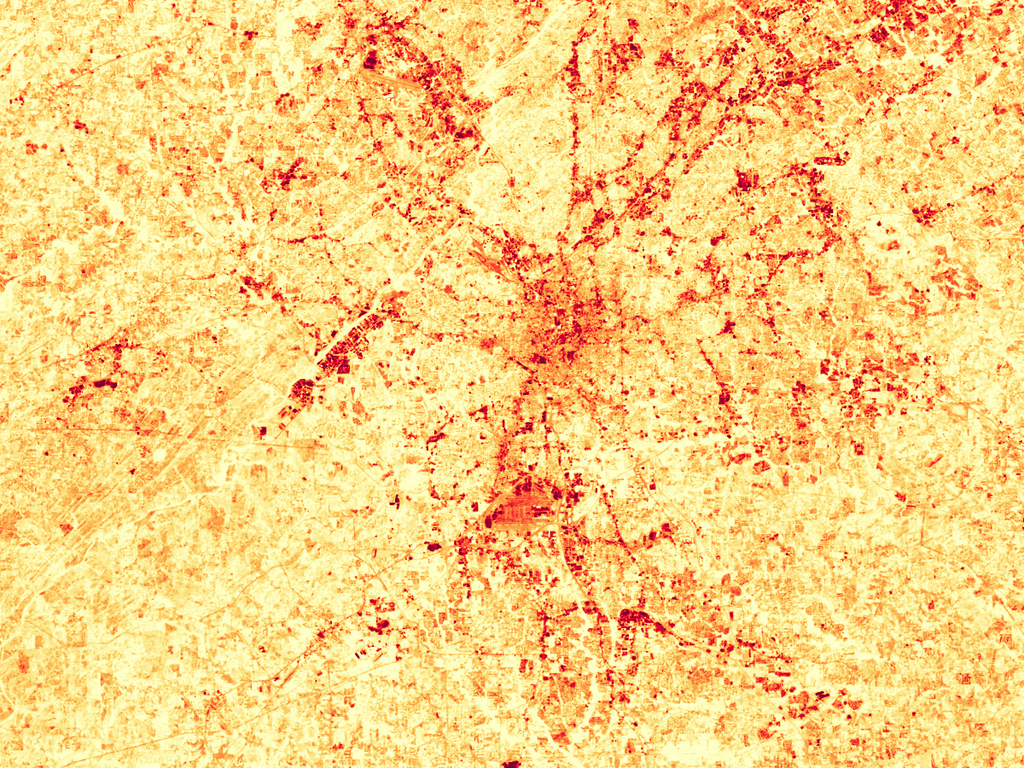

*This is what a city looks like to a thermometer.*

# This Week’s Battlefield

## Two Sides. Two Visions for Our Cities.

PRO-CLIMATE

= Redesign the City

= “Density done right saves the planet”

PRO-DEVELOPMENT

= Build for Growth

= “Cities drive prosperity — don’t slow them down”

## The Core Tension

| PRO-CLIMATE | PRO-DEVELOPMENT |
| --- | --- |
| Green infrastructure mandatory | Economic growth comes first |
| Compact cities, less sprawl | Expand to meet demand |
| Regulate building emissions | Incentivize, don’t restrict |
| Retrofit old buildings | Build new efficient ones |

Keep this tension in mind. It’ll shape everything we discuss today.

# But First: A Number That Should Bother You

## Wait, What?

Cities cover just **3%** of the Earth’s land surface.

They produce **over 70%** of global CO₂ emissions.

And consume **78%** of the world’s energy.

**The built environment isn’t just affected by climate change. It’s *driving* it.**

## More Numbers That Don’t Add Up

- By 2050, **68%** of the world’s population will live in cities (UN)
- NYC’s Central Park can be **up to 5°C cooler** than the streets just 200 metres away — same day, same city
- Vienna turns **250,000 tonnes of garbage** into heat for 60,000 homes — in a building designed by an artist
- Hong Kong buildings account for **over 60%** of the city’s electricity consumption — and **90%** of that electricity comes from fossil fuels

# Anthropogenic Behaviour

## A Word You Already Know

**Anthropogenic**: of, relating to, or resulting from the influence of human beings on nature.

You’ve heard this in Week 2 (food systems), Week 3 (fashion), Week 4 (energy).

But this week it becomes *architectural*. The question isn’t just what we consume — it’s **what we build.**

Buildings don’t just *use* energy. They **shape the microclimate** of the city around them.

“We shape our buildings; thereafter they shape us.”

— Winston Churchill, House of Commons, 28 October 1943, debating whether to rebuild the bombed chamber

He was talking about Parliament. He could have been talking about the climate.

# The Metropolis

## Fritz Lang Saw It Coming

**Metropolis** (1927)

A film set in the year **2026.**

That’s… *this year.*

Fritz Lang imagined a city of towering skyscrapers, underground workers, and a society split between those who plan and those who labour.

**How wrong was he?**

[video not shown]

*Fritz Lang’s Metropolis (1927) — a vision of the year 2026*

## What Makes a Metropolis?

**Characteristics:**

- High population density
- Diverse cultural and economic activities
- Complex infrastructure systems
- Unique blend of modern and traditional architecture
- Hub for innovation, entrepreneurship, and creativity
- Centre for education, healthcare, and entertainment

**Challenges:**

- Traffic congestion and air pollution
- Inadequate housing and overcrowding
- Strain on public services and infrastructure
- Affordability crises
- **Reverse Urbanization** — the suburban pull

## Why Does ANYBODY Want to Stay?

- **Economic Opportunities**: Jobs, pay grades, larger talent pool, startup ecosystems
- **Cultural Diversity & Entertainment**: Theatre, museums, people
- **Education & Research**: Universities, institutions
- **Infrastructure & Transportation**: Connectivity
- **Networking & Collaboration**: Proximity = opportunity

**The metropolis is a climate problem *and* a climate solution.** That’s the paradox.

## Reverse Urbanization

**Definition**: The process of metropolitan residents moving *out.*

**Known causes:**

- Housing affordability
- High cost of living
- Crowdedness

**Impact:**

- Shift in population dynamics
- Growth in smaller cities and towns
- **What does it mean for the metropolis?**

When people flee cities, does the climate problem follow them — or just spread out?

# The Climate Footprint of a City

“A city is not an accident but the result of coherent visions and aims.”

— Léon Krier, *The Architecture of Community*, Island Press, 2009

If the city is designed, then its climate footprint is designed too. By us.

## Urban Heat Island: The Invisible Architecture

Every surface you see in a city — **concrete, glass, asphalt, steel** — absorbs heat during the day and radiates it at night.

This makes metropolitan areas **1–3°C hotter** than surrounding rural areas.

That’s not weather. That’s **architecture.**

This is the **Urban Heat Island** (UHI) effect — and it’s why your city is literally hotter than the countryside.

## Why UHI Matters More Than You Think

It’s not just discomfort. The UHI effect triggers a **cascade**:

1. **Higher temperatures** → more air conditioning demand
2. **More AC** → more electricity consumption
3. **More electricity** → more fossil fuel burning (remember: HK is 90% fossil-powered)
4. **More burning** → more heat → **the city gets even hotter**

This is a **positive feedback loop.** The hotter the city gets, the more energy it uses to cool down, which makes it hotter.

**UHI is Week 10’s “systems thinking” in miniature.** Remember this when we get there.

## See It: How a City Traps Heat

[video not shown]

*Vox (~7 min). Thermal cameras reveal Phoenix’s UHI. The twist: wealthy neighbourhoods are cooler than poor ones. Heat is an inequality problem.*

## One Image. One Number.

**3%** of land.

**70%** of CO₂.

That’s cities. That’s *us.*

## Metropolis & Climate Change

Five ways growing architecture affects climate:

| Impact | Detail |
| --- | --- |
| **Urban Heat Island** | Concrete & glass trap heat; cities 1–3°C hotter |
| **Energy Consumption** | Per capita energy demand concentrates in cities |
| **Transportation Emissions** | Cities as logistics hubs — commuting, freight |
| **Waste Management** | More waste per area; burning → GHG; landfills → methane |
| **Water Scarcity** | Large, concentrated demands strain supply |

# Case Study 1: New York City

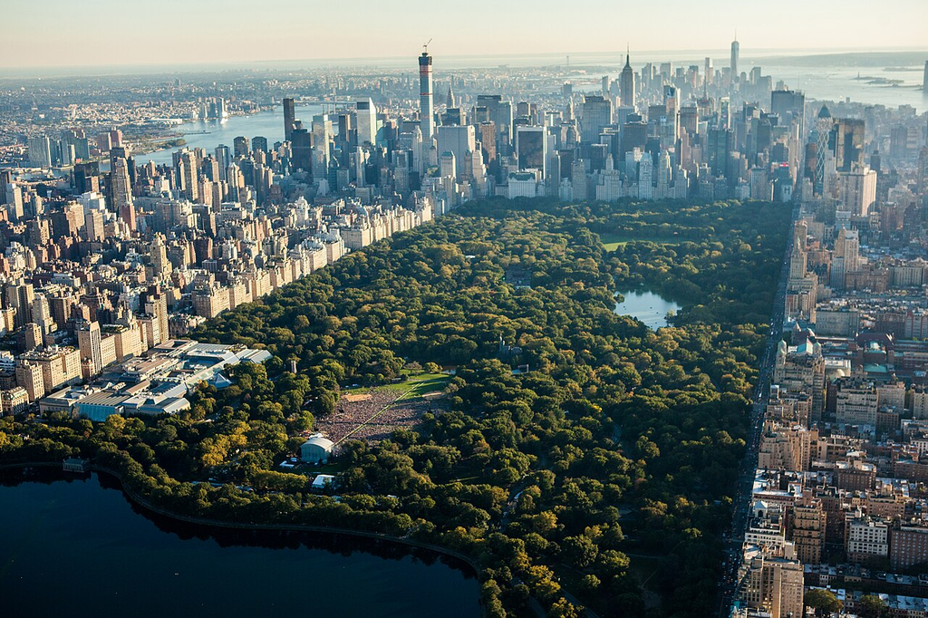

Central Park from above — a 3.4 km² green rectangle holding back the heat of Manhattan.

## The Paradox of Central Park

NYC’s population has remained relatively steady despite everything — because of:

- **Diverse economy** (finance, tech, creative industries)
- **World-class cultural offerings** (museums, Broadway, food)
- **Continued investment** in infrastructure and public services

The city continues to attract people due to its unique combination of known and unknown opportunity.

But here’s the thing: NYC’s Central Park — 3.4 km² of green — drops the temperature around it by up to **5°C** compared to Midtown. **One park. Five degrees.**

# Waste-to-Energy: Turning the Problem Into the Solution

## WtE: Harvesting Energy From Anthropogenic Activity

**How it works:**

- Converts solid waste materials into usable energy
- Combustion/thermal treatment of waste
- Heat produces steam → drives turbines → generates electricity

**Why it matters:**

- Worldwide WtE market to reach **USD $66 billion by 2032** (Spherical Insights, 2023)
- Recovers resources, reduces landfill use (methane drop)
- Reduces reliance on fossil fuels

But is burning waste really “clean”? That depends on where you draw the system boundary. (Sound familiar?)

“The straight line is godless and immoral. The straight line is not a creative line, it is a duplicating line, an imitating line.”

— Friedensreich Hundertwasser, *Mould Manifesto Against Rationalism in Architecture*, 1958

The man who made a trash plant beautiful. You’re about to see why.

# Case Study 2: Vienna’s Spittelau Incinerator

[figure not shown]

Spittelau waste incineration plant, Vienna — redesigned by Friedensreich Hundertwasser. An incinerator that people *want* to visit.

## The World’s Most Beautiful Trash Plant

A 1960s incinerator, redesigned in the 1980s by artist **Friedensreich Hundertwasser.**

**The numbers:**

- Processes **250,000 tonnes** of waste per year
- Generates **60 GWh** of electricity
- Produces **500 GWh** of district heating
- Heats **~60,000 Viennese homes**

An incinerator that people *want* to visit. A tourist attraction. Architecture solving a climate problem while **looking good doing it.**

# Case Study 3: Los Angeles Water Conservation

[figure not shown]

Ivanhoe Reservoir, Los Angeles — 96 million shade balls deployed to reduce evaporation during California’s drought.

## When a Metropolis Runs Dry

LA’s approach to water scarcity — a preview of what many cities will face:

- **TIP 1:** Leverage to save water *while* using water (efficiency at point of use)
- **TIP 2:** Limit/stop using water under certain scenarios (restrictions)
- **TIP 3:** Free government service to audit your private water system
- **TIP 4:** Rebate for changing landscaping to drought-tolerant plants (“Cash for Grass”)

Notice: these are a mix of individual behaviour change and structural incentives. That tension will explode in Week 6 when we talk about capitalism.

# Let’s Bring It Back to HK

## Hong Kong: A Metropolis Under Pressure

**What/how/why might you care about this topic?**

- **Livelihood planning:** Future career/family plans — choosing between metropolis and countryside/suburbs
- **Beyond simple engagement:** Tree-planting campaigns, local community gardens, community-based sustainability efforts
- **Alternatives to city life:** What does it mean to move to suburbs — economically *and* environmentally?

HeGang (鶴崗) in China: a city where apartments cost less than a phone. Is *that* the future — or just urban decay with a viral marketing campaign?

“The greenest building is the one that is already built.”

— Carl Elefante, FAIA, *Forum Journal*, National Trust for Historic Preservation, 2007

Or is it? That’s what we’re about to debate.

## This Week’s Debate Motion

**“This house believes that Hong Kong should prioritise green retrofitting of existing buildings over new development to meet its 2050 carbon neutrality target.”**

PRO-CLIMATE: Retrofit first — new builds are carbon-heavy.

PRO-DEVELOPMENT: Build new, build efficient — retrofitting old buildings is a money pit.

# Your Cheatsheet

## Pro-Climate Expert/KOLs Cheatsheet

**Issues and Actions Proposed:**

- **Compact Urban Design** — less sprawl, more density with green spaces
- **Renewables in Buildings** — rooftop solar and alternatives
- **Green Infrastructure** — eco-certified buildings (LEED, BEAM Plus)
- **Sustainable Transit** — MTR expansion, electric buses
- **Actionable HK2100 solutions:**
  - Urban greenery expanded — vertical gardens, expanded parks
  - More efficient HVAC options
  - Mandatory energy audits for commercial buildings

## Pro-Development Expert/KOLs Cheatsheet

**Issues and Actions Proposed:**

- **Economic Prioritisation** — urbanisation is a major driver of HK’s economy
- **Efficiency Overhaul** — existing building renovation/retrofit needs to happen *and will result in more GHG emissions* (during construction)
- **Loosened Regulation** via public policy to improve development
- **Practical next steps:**
  - Integrated Waste Management Facilities — Waste Incineration Plants Expansion (HK EPD)
  - Public-private partnerships for infrastructure
  - Smart city technology investment

# Group Assignment Time!

## Presentation Countdown

00:00

# This Week’s Conceptual Takeaway

## The Built Environment Is a Climate Actor

Before this week, “climate change” might have felt like an *atmosphere* problem.

Now you know: **every building is a climate decision.**

- What it’s made of (concrete = 8% of global CO₂)
- How it’s cooled (AC → fossil fuels → more heat)
- Where it’s placed (UHI feedback loop)
- What happens to its waste (landfill vs. WtE)

**Your portable takeaway:** The built environment isn’t background — it’s the biggest system boundary we’ve seen yet.

# The Persuasion Playbook | Strategy #4

## The Anchoring Trap

Realtors show you a terrible, overpriced house **first**.

The second house — still overpriced — looks reasonable.

**You don’t evaluate houses. You evaluate differences from the anchor.**

## The Science

This is **Anchoring** (Tversky & Kahneman, 1974).

The first number you hear distorts all subsequent judgment — even when it’s obviously irrelevant.

In experiments, people estimated higher values after spinning a **random wheel** with higher numbers.

**The brain cannot ignore the anchor.**

## You Just Saw It

When someone opened with an extreme number:

*“AI could consume 30% of global electricity by 2040. Even the conservative estimate is 12%.”*

Now 12% sounds reasonable. But 12% is still catastrophic.

**The anchor did its job.**

## Next Week’s Challenge

**Lead with the extreme. Then offer the “reasonable” version.**

Set the anchor before they do.